# BANA 4080: Introduction to Data Mining with Python

Week 11: Tree-Based Models

## Welcome to Week 11

- Quick overview of today’s plan:
  - Where linear models fall short
  - Decision trees: learning to ask yes/no questions
  - Why a single tree is fragile
  - Random forests: combining many trees into one strong model
  - Opening the black box with feature importance

## 📓 Follow Along in the Notebook

**Week 11 Lecture Notebook**

Open the companion notebook in Colab now and follow along as we work through today’s examples on decision trees, random forests, and feature importance.

[figure not shown]

Open In Colab

# Week 10 Recap

## Last Week in 60 Seconds

📈 Logistic regression

The S-curve turns a linear score into a **probability** between 0 and 1

😴 The lazy model

Predicting “No default” for everyone scored **96.7%** accuracy. Always compare to a baseline

🧮 Precision & recall

**Precision:** when we flag, are we right?

**Recall:** of the real defaulters, how many did we catch?

🎚️ The threshold dial

The business’s error costs, not the default 50%, decide where to set it

**Tip**

Today we change the **model**, not the workflow: split → fit → predict → evaluate against a baseline.

# All Models Are Wrong, But Some Are Useful

## Linear Models Struggle with Non-Linear Patterns

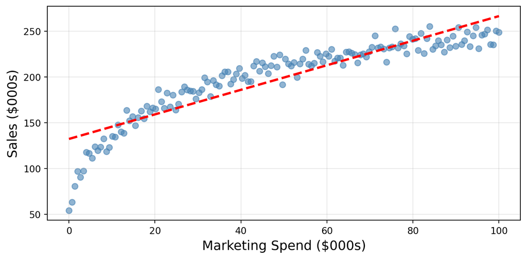

**Caution**

**Real business data rarely follows straight lines**

## Linear Models Miss Interactions

|  | **Premium Brand** | **Unknown Brand** |
| --- | --- | --- |
| **High Quality** | $200 | $80 |
| **Low Quality** | $120 | $40 |

**The Pattern:**

High quality means different things in different contexts.

Linear models struggle to capture these interactions without manual specification.

**Same Quality → Different Prices (Context Matters!)**

Same quality product gets wildly different prices based on brand. Linear models assume quality has one fixed effect - but here it depends on context.

## Linear Models Are Hard to Explain

**Option 1: Linear Model**

$$P(\text{default}) = \frac{1}{1+e^{-(\beta_0 + 0.0032 \cdot \text{balance} - 0.0015 \cdot \text{income} + ...)}}$$

*“For each $100 increase in balance, the log-odds of default increase by 0.32…”*

**Option 2: Decision Tree**

**If balance > $1,200** **Then 85% default risk**

*“If their balance is over $1,200 they have an 85% probability of defaulting.”*

**Which would you present to your boss?**

## What If There Was a Better Way?

**Decision trees** address each of these limitations:

〰️ Non-linear patterns

Capture curves and plateaus naturally, with no transformations needed

🔀 Interactions

Discover on their own that quality matters differently for premium and unknown brands

✂️ Thresholds

Find the cutoffs that matter (*balance > $X*) directly from the data

🗣️ Clear rules

Produce plain if-then rules that mirror how people make decisions

# Decision Trees: The if-else of ML!

## Anatomy of a Decision Tree

A tree is a series of **yes/no questions**:

- **Root node:** the first question, asked of everyone
- **Internal nodes:** follow-up questions
- **Leaves:** the final answer (the prediction)
- **Depth:** how many questions deep it goes

The tree **learns** which questions to ask, and the cutoffs, from the data.

```
flowchart TD
    B{"<b>ROOT</b><br/>Income > 50K?"}
    B -->|Yes| C{"Credit Score > 700?"}
    B -->|No| D{"Has Co-signer?"}
    C -->|Yes| E["<b>LEAF</b><br/>Approve"]
    C -->|No| F["<b>LEAF</b><br/>Deny"]
    D -->|Yes| G["<b>LEAF</b><br/>Approve"]
    D -->|No| H["<b>LEAF</b><br/>Deny"]

    style B fill:#e3f2fd,stroke:#1976d2,stroke-width:3px
    style C fill:#fff3e0,stroke:#f57c00,stroke-width:2px
    style D fill:#fff3e0,stroke:#f57c00,stroke-width:2px
    style E fill:#c8e6c9
    style F fill:#ffcdd2
    style G fill:#c8e6c9
    style H fill:#ffcdd2
```

## Which Question Is Better?

Each jar holds 20 customers: ● paid, ● defaulted. A good question **sorts** them:

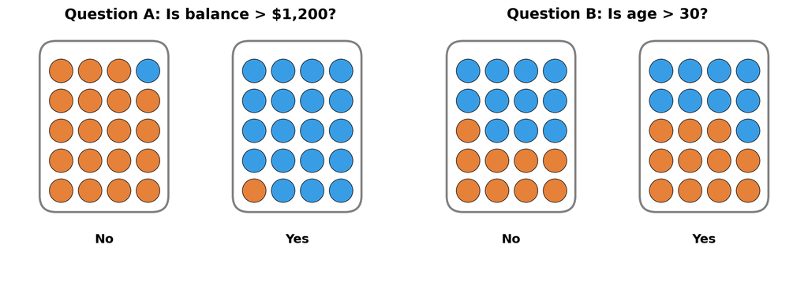

**Question A** produces two jars that are each almost one color. That’s what the tree is looking for: **pure** groups.

## Measuring Messiness: Gini Impurity

**Gini** = if you pull two customers out of a jar, the chance they **don’t match**.

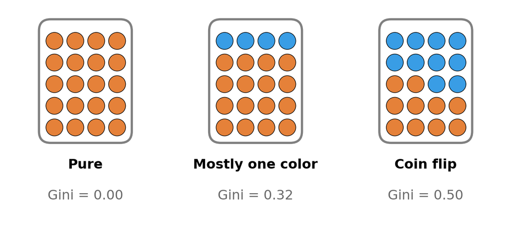

**How the tree picks a question (the CART algorithm):**

1. Try **every cutoff** for **every feature**
2. Score each one by the (size-weighted) Gini of the two jars it creates
3. Keep the **lowest**, then repeat inside each new jar

## You Be the Algorithm

40 real customers from the Default data (20 defaulted, 20 didn’t). **Drag the slider** to try different balance cutoffs. Where is the weighted Gini lowest?

[interactive chart not shown]

## Demo: Build Your First Tree

Let’s build a decision tree to predict credit card defaults, using the same data and split as last week:

```python
from ISLP import load_data
from sklearn.tree import DecisionTreeClassifier, plot_tree
from sklearn.model_selection import train_test_split

# Load the Default data and convert the Yes/No columns to 1/0
Default = load_data('Default')
Default['default'] = (Default['default'] == 'Yes').astype(int)
Default['student'] = (Default['student'] == 'Yes').astype(int)

X = Default[['student', 'balance', 'income']]
y = Default['default']

X_train, X_test, y_train, y_test = train_test_split(
    X, y, test_size=0.3, random_state=42, stratify=y
)

# Build a shallow tree (max_depth=3 keeps it readable)
tree_model = DecisionTreeClassifier(max_depth=3, random_state=42)
tree_model.fit(X_train, y_train)
```

Same `.fit()` as every model so far. `max_depth` caps how many questions deep the tree can go.

## Reading Our Tree

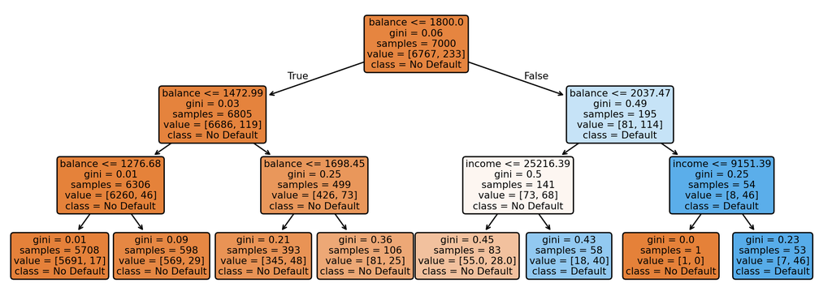

**How to read a node** (using the top box, drawn with `plot_tree()`):

- `balance <= 1800.0`: the **question**. True → go left, False → go right
- `gini = 0.06`: how **mixed** the node is (0 = pure)
- `samples = 7000`: training customers who **reach** this node
- `value = [6767, 233]`: how many **paid** vs. **defaulted**
- `class = No Default`: the **majority**, which is what this node predicts
- Color: orange = No Default, blue = Default; **darker = purer**

## How the Tree Makes a Prediction

A new customer: not a student, **$2,000** balance, **$40,000** income

```python
customer = pd.DataFrame({
    'student': [0],
    'balance': [2000],
    'income': [40000]
})
tree_model.predict(customer)
```

```
array([1])
```

```python
tree_model.predict_proba(customer).round(2)
```

```
array([[0.31, 0.69]])
```

**Red path:** balance > 1,800 → balance ≤ 2,037 → income > 25,216 → a leaf with 18 paid / 40 defaulted → **Default** (69%)

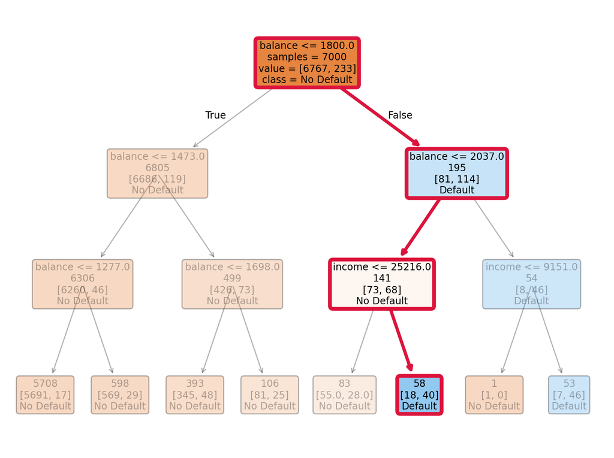

## Did the Tree Beat the Lazy Model?

Last week, logistic regression barely beat predicting “No default” for everyone. Does a tree do better?

```python
from sklearn.metrics import accuracy_score, recall_score

y_pred = tree_model.predict(X_test)
lazy_pred = np.zeros(len(y_test))   # predict "No default" for everyone

print(f"Lazy model accuracy: {accuracy_score(y_test, lazy_pred):.1%}")
print(f"Tree accuracy:       {accuracy_score(y_test, y_pred):.1%}")
print(f"Tree recall:         {recall_score(y_test, y_pred):.2f}")
```

```
Lazy model accuracy: 96.7%
Tree accuracy:       97.1%
Tree recall:         0.37
```

**Same trap as last week**

The tree beats doing nothing by less than half a percentage point and catches only **37 of the 100** defaulters. A new model doesn’t change the rules: **compare to a baseline and pick metrics that fit the business.**

## What the Tree Sees: Boxes

Every question draws a line, so every leaf is a **box** (shaded by its **share of defaulters**). More depth = more questions = **smaller boxes**. **Drag the slider:**

[interactive chart not shown]

## Trees Predict Numbers Too

For a number, each leaf predicts the **average** of its training rows, so the tree draws a **staircase**. More depth = **more, smaller steps**. **Drag the slider:**

[interactive chart not shown]

Same idea, two changes: splits minimize **squared error** instead of Gini, and you use `DecisionTreeRegressor`.

## How Deep Should a Tree Go?

**Too shallow misses the pattern; too deep memorizes the noise**

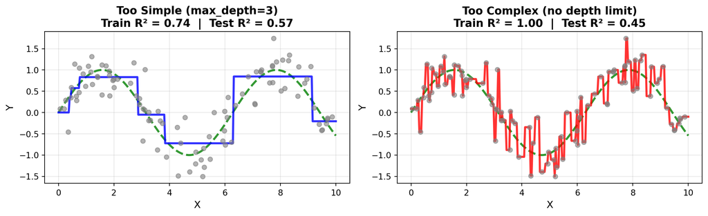

**Depth cuts both ways**

Deeper trees capture **finer patterns**, but past a point they **memorize individual training points** (week 9’s memorizer). Too shallow misses the pattern; too deep chases noise. A single tree forces us to pick one spot on that dial.

# Random Forests: Wisdom of Crowds

## Another Weakness: Instability

**Small changes in data → a different rule book**

Three depth-2 trees predicting Boston home values (in $1,000s), each trained on a slightly different random sample of the **same** data:

📖 Tree 1

**First question:** is `rm` ≤ 6.9?

- rm ≤ 6.9 and lstat ≤ 14.4 → **$23K**
- rm ≤ 6.9 and lstat > 14.4 → **$15K**
- rm > 6.9 and rm ≤ 7.4 → **$34K**
- rm > 6.9 and rm > 7.4 → **$45K**

📖 Tree 2

**First question:** is `lstat` ≤ 9.5?

- lstat ≤ 9.5 and rm ≤ 7.0 → **$26K**
- lstat ≤ 9.5 and rm > 7.0 → **$40K**
- lstat > 9.5 and lstat ≤ 15.0 → **$21K**
- lstat > 9.5 and lstat > 15.0 → **$14K**

📖 Tree 3

**First question:** is `lstat` ≤ 7.7?

- lstat ≤ 7.7 and rm ≤ 7.4 → **$29K**
- lstat ≤ 7.7 and rm > 7.4 → **$44K**
- lstat > 7.7 and lstat ≤ 14.9 → **$22K**
- lstat > 7.7 and lstat > 14.9 → **$14K**

**Same data, different rule books**

The **first question**, the **cutoffs**, and the **predictions** all change. Which tree would you use to explain home prices to a client, and what happens to your story when the data is refreshed next month?

## Random Forests: Two Key Ingredients

Random Forests improve on single decision trees through two main modifications:

**1. Bootstrap Aggregating (Bagging)**

Train many trees on different random samples of data

**2. Feature Randomness**

Each tree considers only a random subset of features at each split

**Let’s see how each one works…**

## Let’s Build Bootstrap Samples

Each student picks a customer at random, **with replacement**: the same customer can be picked again. **Click** the customer each student calls out:

Original data

click a customer to draw them

Bootstrap sample 1

Bootstrap sample 2

Bootstrap sample 3

- Some customers get picked **twice or more**; others are **left out** entirely
- Every tree trains on its own sample, so every tree sees a slightly different version of the data

## Bootstrap Aggregating (Bagging)

1,000 noisy points. Each tree is fully grown on its own random draw of **100 points** (with replacement), then we **average** the trees. Start at **0 trees**, then **drag the slider**:

[interactive chart not shown]

## The Problem with Bagging Alone

**What if one or two features are much stronger than the others?**

We bagged 100 trees on the Boston data and recorded the **first question** each tree asks:

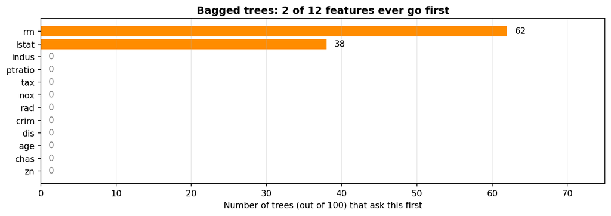

**Problem: Tree Correlation**

Every tree opens with `rm` or `lstat`. Trees that ask the same questions **look alike and make the same mistakes**, so averaging them doesn’t cancel much out.

## The Fix: Feature Randomness

Before **every** split, draw a random **4 of the 12** features from a hat. The tree may only ask about those.

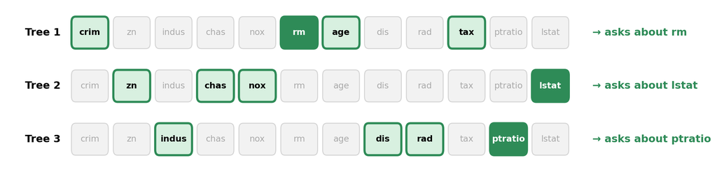

Light green = drawn from the hat; dark green = the best of those. No `rm`? The tree **has to** ask something else, so the trees end up different.

## More Features Get a Turn

Same census, but each split may only use a **random 4 of the 12** features:

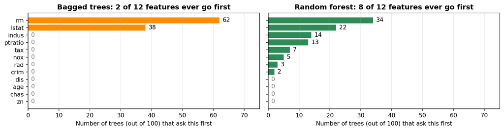

**Tip**

No `rm` or `lstat` on the menu? The tree opens with something else. **Different first questions → different trees → different mistakes.**

## Why the Forest Works

Think of each tree as a **home appraiser**. Our forest’s 100 appraisers value 3 homes they’ve never seen, colored by the **first question** each tree asks:

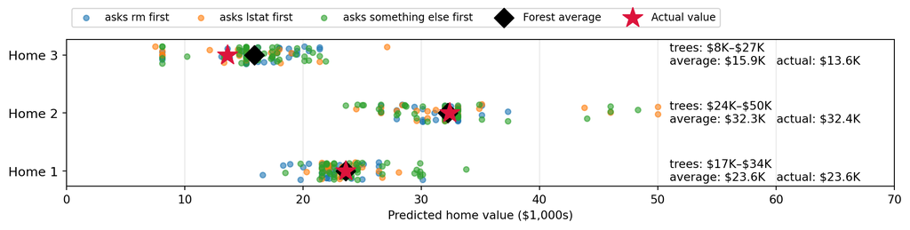

🌳🌳🌳 Ingredient 1: Averaging

Each tree misses by a lot, in **both directions**. Averaging 100 of them cancels most of those misses.

🎲 Ingredient 2: Feature randomness

Averaging only cancels mistakes that **differ**. Here 44 of 100 trees open with something other than `rm` or `lstat`, so their mistakes differ more.

## Does It Pay Off?

Test error on the Boston data as we add trees:

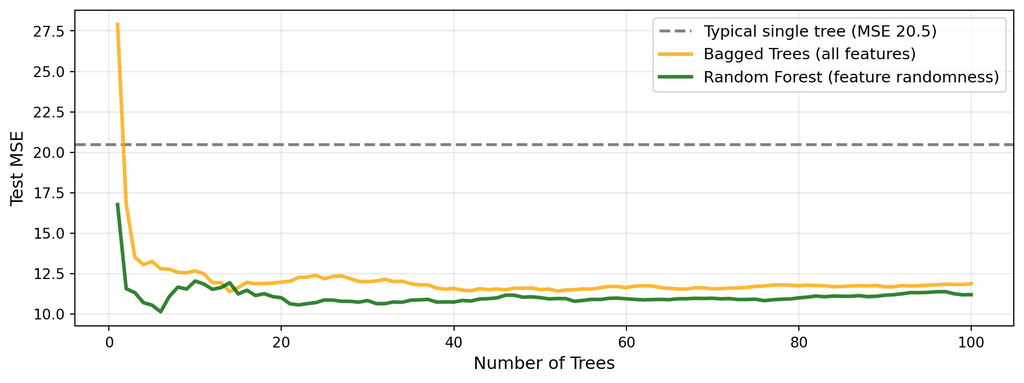

**Tip**

**Averaging** delivers the big drop (gray → orange). **Feature randomness** adds an extra gain on top (orange → green). Random forests get both.

## Demo: Single Tree vs Random Forest

Let’s compare one tree to a forest on the Boston housing data:

```python
from sklearn.tree import DecisionTreeRegressor
from sklearn.ensemble import RandomForestRegressor

# Boston housing: predict median home value (medv, in $1,000s)
Boston = load_data('Boston')
X = Boston.drop(columns='medv')
y = Boston['medv']
X_train, X_test, y_train, y_test = train_test_split(X, y, test_size=0.3, random_state=42)

# One tree vs. a forest of 100 trees (both kept shallow for illustration)
single_tree = DecisionTreeRegressor(max_depth=3, random_state=42)
single_tree.fit(X_train, y_train)

rf_model = RandomForestRegressor(n_estimators=100, max_depth=3, random_state=42)
rf_model.fit(X_train, y_train)
```

`n_estimators` sets how many trees are in the forest. Everything else works like the models you already know.

## Evaluate Them the Same Way

```python
from sklearn.metrics import root_mean_squared_error

results = []
for name, model in [('Single tree', single_tree), ('Random forest', rf_model)]:
    results.append({
        'model': name,
        'train R²': model.score(X_train, y_train),
        'test R²': model.score(X_test, y_test),
        'test RMSE ($K)': root_mean_squared_error(y_test, model.predict(X_test))
    })

pd.DataFrame(results).round(3)
```

|  | model | train R² | test R² | test RMSE ($K) |
| --- | --- | --- | --- | --- |
| 0 | Single tree | 0.825 | 0.773 | 4.114 |
| 1 | Random forest | 0.878 | 0.805 | 3.809 |

**Nothing new here**

Same train/test split and same metrics as week 9 (RMSE, R²). For a classification forest, we’d use week 10’s tools: the lazy-model baseline, confusion matrix, precision, and recall. **Only the model changed.**

# Feature Importance: Opening the Black Box

## Accurate, But Can You Explain It?

📈 Linear & logistic regression

**Read the coefficients** ✅

*“Each extra $1,000 of balance raises default risk”*

🌳 Decision tree

**Follow the rules** ✅

*“Balance over $1,800 → much higher risk”*

🌲🌲🌲 Random forest

**Hundreds of trees** ❌

No coefficients, no single path to follow

**The VP’s question**

*“Your forest flags 500 customers who are likely to churn. Great. **Why** are they at risk, and what should we do about it?”*

## Two Questions We Can Answer

Even without coefficients, we can answer two questions about **any** model:

🏆 Which features matter most?

**Feature importance** ranks the inputs the model relies on

📈 How do they move the prediction?

**Partial dependence plots (PDPs)** show how the prediction changes as one feature changes

**⬇ What each one lets you tell the VP** (churn example):

**Answers “*Why* are they at risk?”**

*“The model leans most on **service calls** and **contract type**. That’s where the risk comes from.”*

**Answers “*What* should we do?”**

*“Risk **jumps after the 3rd service call**, so reach out before the 4th.”*

## Two Ways to Measure Importance

🌳 Gini importance

*How much did this feature help the trees split during training?*

Built in: `.feature_importances_`

⚡ Fast, but only looks at **training** data

🔀 Permutation importance

*How much worse does the model do on test data when we scramble this feature?*

`permutation_importance()`

🐢 Slower, but measures what matters on **new** data

**Tip**

Take a quick look with Gini, then **confirm with permutation importance**.

## How Gini Importance Is Computed

Back to our credit-default tree. Every split makes its groups **purer**; that drop in Gini is **credited to the feature** the split used:

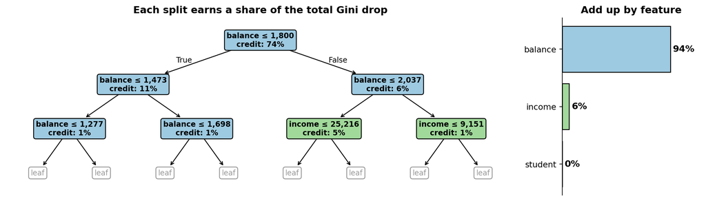

**Recipe:** ① measure each split’s **Gini drop** (bigger groups count more) → ② **credit** it to the split’s feature → ③ **add up** by feature. For a **forest**, average across all the trees.

## Demo: Gini Importance

What drives our random forest’s housing price predictions? Start with the built-in importance:

```python
gini_importance = (
    pd.DataFrame({'feature': X_train.columns, 'importance': rf_model.feature_importances_})
    .sort_values('importance', ascending=False)
    .reset_index(drop=True)
)

gini_importance.head()
```

|  | feature | importance |
| --- | --- | --- |
| 0 | rm | 0.470899 |
| 1 | lstat | 0.425896 |
| 2 | dis | 0.060453 |
| 3 | crim | 0.019015 |
| 4 | ptratio | 0.011493 |

**Note**

Same recipe as the last slide, averaged across all 100 trees. Each value is that feature’s **share** of the total impurity drop.

## Permutation importance

**The Idea: Scramble a Column**: Shuffle the `rm` column of the test set (so each home gets some *other* home’s room count) and watch the predictions change:

**Original test data**

| rm | lstat | predicted value ($K) |
| --- | --- | --- |
| 6.4 | 9.0 | 22.2 |
| 6.8 | 3.5 | 28.7 |
| 6.0 | 18.1 | 15.7 |
| 6.1 | 5.5 | 24.6 |
| 6.3 | 17.3 | 16.9 |
| 6.3 | 12.0 | 22.0 |

**`rm` scrambled**

| rm | lstat | predicted value ($K) |
| --- | --- | --- |
| 6.1 | 9.0 | 22.1 |
| 8.0 | 3.5 | 44.0 |
| 6.0 | 18.1 | 15.7 |
| 6.0 | 5.5 | 24.6 |
| 6.9 | 17.3 | 18.3 |
| 6.4 | 12.0 | 22.0 |

**Tip**

Scrambling `rm` breaks its link to price, so test R² drops from **0.81** to **0.40**. **Permutation importance** repeats this for every feature: the bigger the drop, the more the model relied on that feature.

## Demo: Permutation Importance

Each value = the average **drop in test R²** when that column is shuffled (10 times):

```python
from sklearn.inspection import permutation_importance

perm_result = permutation_importance(
    rf_model, X_test, y_test, n_repeats=10, random_state=42, scoring='r2'
)
perm_importance = (
    pd.DataFrame({'feature': X_test.columns, 'importance': perm_result.importances_mean})
    .sort_values('importance', ascending=False)
    .reset_index(drop=True)
)
perm_importance.head()
```

|  | feature | importance |
| --- | --- | --- |
| 0 | lstat | 0.532376 |
| 1 | rm | 0.391215 |
| 2 | dis | 0.051826 |
| 3 | ptratio | 0.016935 |
| 4 | crim | 0.015026 |

## Do the Two Methods Agree?

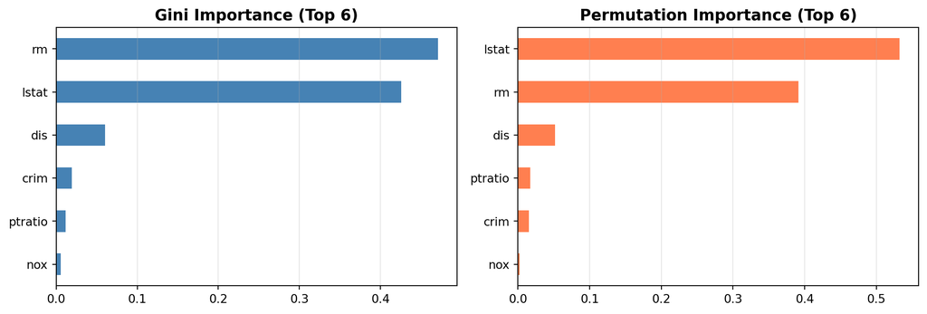

**Tip**

Both methods agree that **`rm`** (average rooms) and **`lstat`** (% lower-status residents) dominate, but they **swap the order**. Gini reflects what the trees used during training; permutation reflects what helps on new data. That’s why we validate with permutation importance.

## What-If: Change Only the Rooms

Importance told us `rm` matters. **How** does it move the prediction? Take 50 real homes, set **every** home’s `rm` to the same value (keep everything else), and ask the forest. **Drag the slider:**

[interactive chart not shown]

## Demo: Partial Dependence Plot

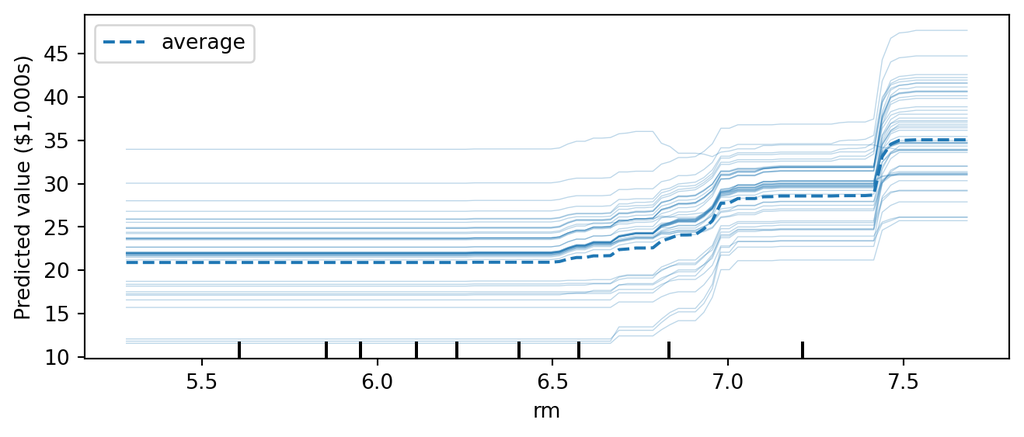

```python
from sklearn.inspection import PartialDependenceDisplay

fig, ax = plt.subplots(figsize=(8, 3))
pdp = PartialDependenceDisplay.from_estimator(
    rf_model, X_train, features=['rm'], kind='both',
    subsample=50, random_state=42, ax=ax
)
pdp.axes_[0, 0].set_ylabel('Predicted value ($1,000s)')
plt.show()
```

**Reading it**

Thin lines = individual homes; dashed line = their **average** (the PDP). Flat near **$21K** until about **6.5 rooms**, then a steep climb: a **tipping point** a linear model would miss.

## PDPs for the Top Features

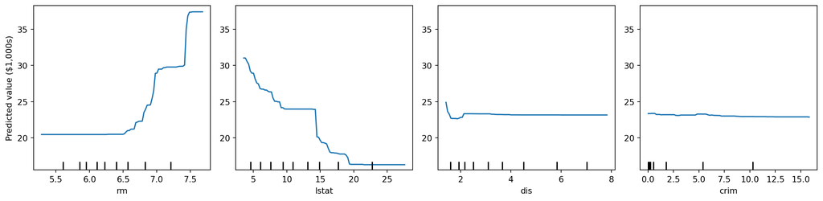

```python
fig, axes = plt.subplots(1, 4, figsize=(14, 3.5))
pdp = PartialDependenceDisplay.from_estimator(
    rf_model, X_train, features=['rm', 'lstat', 'dis', 'crim'], ax=axes
)
for i, panel in enumerate(pdp.axes_.ravel()):
    panel.set_ylabel('Predicted value ($1,000s)' if i == 0 else '')
plt.tight_layout()
plt.show()
```

- **`lstat`**: predicted value falls from about $31K to $16K, then **levels off** past ~20%
- **`dis`** and **`crim`**: nearly flat. Low importance shows up as a **flat PDP**

# Looking Forward

## Key Takeaways

- **Linear models have limits**: they miss curves, thresholds, and interactions unless we build them in by hand
- **Decision trees**: learn if-then rules from data, choosing each split to make the groups as pure as possible
- **Single trees are fragile**: small data changes reshape them, and unlimited trees memorize noise
- **Random forests**: bootstrap samples + feature randomness create diverse trees whose errors cancel out
- **Same evaluation workflow**: train/test split, compare against a baseline, pick metrics that fit the business
- **Interpreting without coefficients**: feature importance shows *which* features matter; PDPs show *how*

## More in Your Readings

🌳 Regression trees & SSE

How trees choose splits when the target is a number

🎛️ Hyperparameters

`max_depth`, `n_estimators`, and `max_features`, and how they trade off accuracy and stability

⚠️ Importance pitfalls

Correlated features, the cardinality trap, and why *important* doesn’t mean *causal*

🔬 Beyond importance

SHAP, LIME, and other explainable AI tools

## Thursday’s Lab

**This Week’s Lab Preview**

In Thursday’s lab, you’ll get hands-on practice with:

- Walking through decision trees, random forests, feature importance, and PDPs on the Boston housing data
- Building trees and forests with different settings to classify breast cancer tumors
- Comparing models and selecting the best one
- Identifying the most important features and interpreting a partial dependence plot

**Homework**

Thursday’s lab will lead into this week’s homework assignment.

## Any Final Questions?

- About decision trees and how they choose splits?
- About random forests?
- About feature importance and partial dependence plots?
- About Thursday’s lab?

**See you Thursday for hands-on tree-based modeling!**